# Report of genome assemblies

```r
mtar <- read_delim("/Users/acas/Dropbox/Post-docs/Roux_Lab/genome_assembly/quast_reports/Mtar/report.tsv",
    delim = "\t", quote = "")

colnames(mtar) <- c("Stats", "Mtar_wtdbg2_LRScaf_LR", "Mtar_canu_LRScaf_LR", "Mtar_merged.wtdbg2.canu_LRScaf_LR",
    "Mtar_wtdbg2_RagTagScaf_LR", "Mtar_wtdbg2_LRScaf_TGS")

mibe <- read_delim("/Users/acas/Dropbox/Post-docs/Roux_Lab/genome_assembly/quast_reports/Mibe/report.tsv",
    delim = "\t", quote = "")

colnames(mibe) <- c("Stats", "Mibe_wtdbg2_LRScaf_LR", "Mibe_canu_LRScaf_LR", "Mibe_merged.wtdbg2.canu_LRScaf_LR",
    "Mibe_wtdbg2_RagTagScaf_LR", "Mibe_wtdbg2_LRScaf_TGS")

maeg <- read_delim("/Users/acas/Dropbox/Post-docs/Roux_Lab/genome_assembly/quast_reports/Maeg/report.tsv",
    delim = "\t", quote = "")

colnames(maeg) <- c("Stats", "Maeg_wtdbg2_LRScaf_LR", "Maeg_canu_LRScaf_LR", "Maeg_merged.wtdbg2.canu_LRScaf_LR",
    "Maeg_wtdbg2_RagTagScaf_LR", "Maeg_wtdbg2_LRScaf_TGS")

busco <- read.delim("/Users/acas/Dropbox/Post-docs/Roux_Lab/genome_assembly/busco_reports/busco_assemblies_closed.txt")
```

Report with assemblies produced using either [Wtdbg2](https://github.com/ruanjue/wtdbg2) or [canu](https://canu.readthedocs.io/en/latest/index.html) as assembler, as well as merging these two assemblies with quickmerge. Scaffolding was tested with [LRScaf](https://github.com/shingocat/lrscaf) (de novo) vs RagTag (using GAGA M. capitatus genome as reference) and gaps were closed testing LR_Gapcloser vs TGS-GapCloser (includes 3 rounds of polishing with [Racon](https://github.com/lbcb-sci/racon)). Each step was followed by a round of polishing with [Polca](https://github.com/alekseyzimin/masurca) (within masurca) followed by polishing with NextPolish except the gap closing step which has only been polished with polca yet. Assemblies were evaluated with Busco v5 and [Quast](http://quast.sourceforge.net/docs/manual.html#sec2) using M. capitatus as reference.

# Busco loci summary

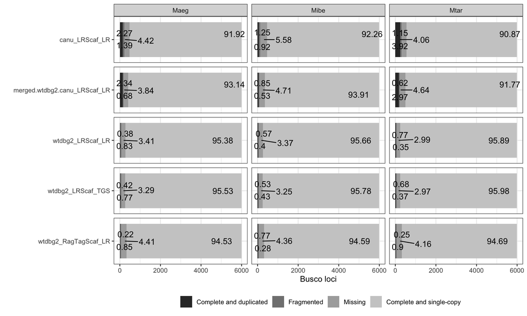

```r
b <- busco %>% pivot_longer(cols = contains("bus")) %>% filter(!name %in% c("bus_T",
    "bus_C")) %>% # arrange(desc(value)) %>%
mutate(species = word(assembly, sep = "_", 1, 1), assembly = word(assembly, sep = "_",
    2, 4), perc = round((value/5991) * 100, 2)) %>% ggplot(aes(x = value, y = fct_rev(fct_inorder(assembly)),
    fill = name)) + geom_bar(stat = "identity", position = position_stack(reverse = TRUE)) +
    geom_text_repel(aes(label = perc), size = 4) + facet_grid(assembly ~ species,
    scales = "free_y") + theme_bw() + labs(y = "", x = "Busco loci", fill = "") +
    scale_fill_grey(labels = c("Complete and duplicated", "Fragmented", "Missing",
        "Complete and single-copy")) + theme(legend.position = "bottom", strip.text.y = element_blank())
b
```

```r
ggsave("/Users/acas/Dropbox/Post-docs/Roux_Lab/genome_assembly/busco_reports/busco_assemblies.pdf",
    b, height = 6, width = 10)
```